# OROCHI Report

OROCHI team

[figure not shown]

[figure not shown]

[figure not shown]

| https://github.com/nioo-knaw/orochi | Contact: l.ariasgiraldo@nioo.knaw.nl , lotte.pronk@wur.nl

All the figures and tables contained in this report are available with publication-ready quality in the output directory of the OROCHI user.

For each of the sections shown in this report, these are the data used:

- Read-based: Quality-controlled shotgun sequencing reads
- Contig-based: Assemblies
- Bin-based: Refined and de-replicated bins

**DISCLAIMER**: This report represents only a visual overview of certain stages of the workflow and should NOT be considered a complete reflection of Orochi’s functionality. Orochi produces a rich and structured set of outputs across numerous directories, not shown here. To truly take advantage of Orochi’s capabilities, users should explore said directories thoroughly and engage with the full range of generated files and results.

### Read-based

*All read-based analysis plots were made using MicrobiotaProcess. For more information, consult their documentation.

#### Quality report (from fastp)

Quality reports were produced at the beginning of the metagenomics analysis, when Orochi used fastp to trim the low-quality reads and remove sequences that should be excluded from further analysis (e.g. polyG tails). Below you can find the link corresponding to each sample.

NOTE: If you click on your samples and cannot visualize any of them, it means you did not download all the necessary directories for the proper display of Orochi’s report. Please refer to the Orochi documentation.

Sam1

Sam10

Sam2

Sam3

Sam4

Sam5

Sam6

Sam7

Sam8

Sam9

#### Alpha diversity

1. Observed and Shannon indexes for all samples, regardless of treatment
2. Boxplot and violin plot of Observed and Shannon indexes per treatment

[figure not shown]

#### Taxonomic abundance

Remember: You already have all these plots (per taxonomic level), there is no need to download them again. Simply look for them in `{OUTDIR}/results/09_plots/1-Reads/`

#### Beta diversity

Bray-Curtis dissimilarity indices are used to calculate pairwise distances between all samples (even the ones that belong to the same treatment), and significance is calculated (Wilcoxon test)

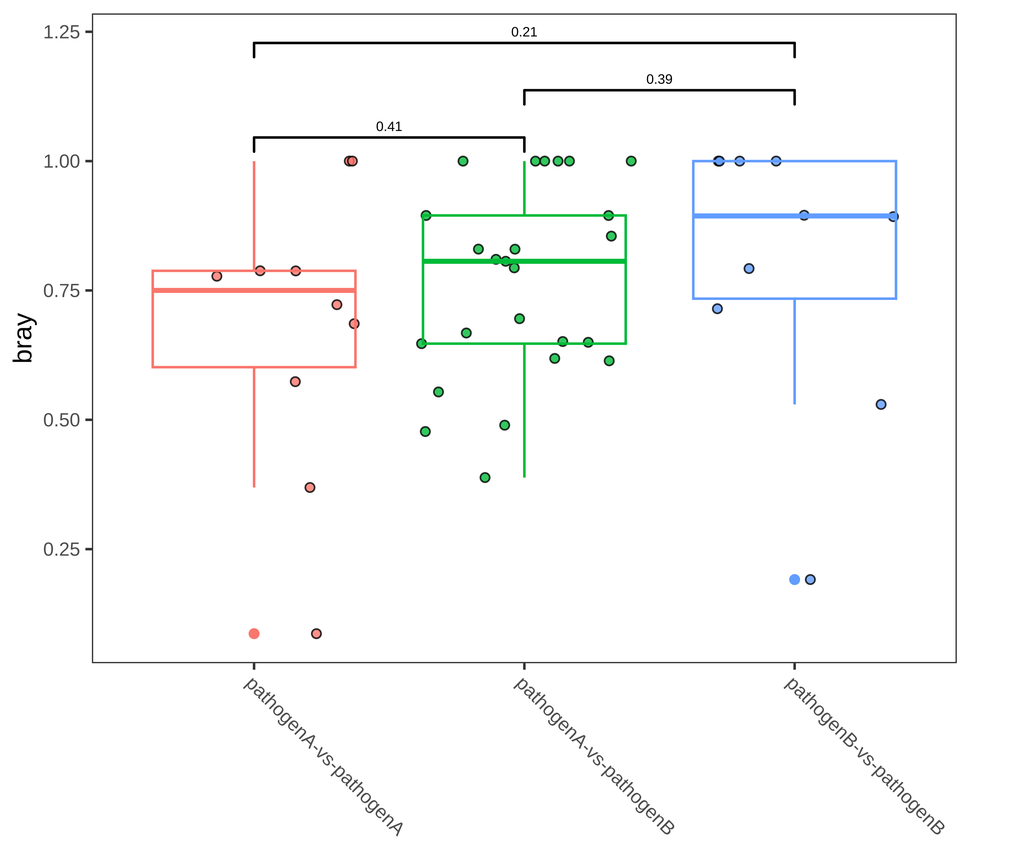

PCoA of all samples. Colors correspond to treatment, and boxplots on the right and top side indicate the distribution of the samples of each treatment along each coordinate. 95% confidence intervals are also plotted.

[figure not shown]

#### Clustering

Dendrogram showing grouping of the whole dataset based on hierarchical cluster analysis, colored based on the treatments found in the metadata fed by the user.

[figure not shown]

### Contig-based

#### Taxonomic annotation

Krona

A

B

#### COG Reference

|  | Description |
| --- | --- |
| J | Translation, ribosomal structure and biogenesis |
| A | RNA processing and modification |
| K | Transcription |
| L | Replication, recombination and repair |
| B | Chromatin structure and dynamics |
| D | Cell cycle control, cell division, chromosome partitioning |
| Y | Nuclear structure |
| V | Defense mechanisms |
| T | Signal transduction mechanisms |
| M | Cell wall/membrane/envelope biogenesis |

[output cut: 15 more lines]

#### antiSMASH results

HTML reports showing BGCs per sample pool, as indicated by the name shown in each button. Buttons in the top row correspond to bacterial results (antiSMASH) and buttons in the bottom row correspond to fungal results (fungiSMASH). Make sure to download the `{OUTDIR}/results/09_plots/rsc/` directory so you can visualize all the elements of the HTMLs.

Remember: These are standalone HTMLs that you can also find in `{OUTDIR}/results/08_BGC/antismash/{pool_name}/{bacterial}` and `{OUTDIR}/results/08_BGC/antismash/{pool_name}/{fungal}`.

Bacterial

Fungal

A

A

B

B

### Bin-based

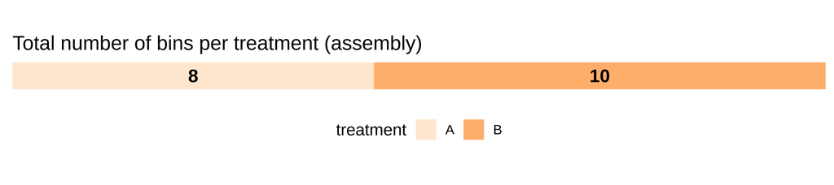

#### Bin quality

Scatterplots per pool showing the completeness and contamination of each bin based on CheckM results. Color corresponds to the full taxonomy assigned to the bin. The threshold that defines whether a bin is good quality or not is dependant on the type of sample processed. In general, we suggest to look for a minimum of 70% completeness and a maximum of 10% contamination. You can find more data about your bins in `{OUTDIR}/results/06_binning`.

| View interactive plot |
| --- |
| View interactive plot |